# 第六章 信号与系统的时域和频域特性

马越

北京理工大学机械与车辆学院  
Email: yuema@bit.edu.cn

## 目录

- **1. 傅里叶变换的模和相位表示**
- 2. 线性时不变系统频率响应的模和相位表示
- 3. 理想频率选择性滤波器的时域特性
- 4. 非理想频率选择性滤波器的时域特性
- 5. 一阶与二阶连续时间系统
- 6. 一阶与二阶离散时间系统
- 7. 系统的时域和频域分析实例

## 引言

∴ 在时域，系统的特性由 $h(t)$ 或 $h(n)$ 描述；

∴ 在频域，系统的特性由 $H(j\omega)$或 $H(e^{j\omega})$ 䅦述；

- 在LTI 系统分析中，时域中的微分（差分）方程和卷积运算在频域都变成了代数运算，利用频域分析往往特别方便。
- 系统的时域特性与频域特性是相互制约的。在进行系统的分析与设计时，要权衡考虑系统的时域与频域特性。

## 傅里叶变换的模–相位表示

$$X(j \omega)=|X(j \omega)| e^{j \arg X(j \omega)}, \quad X\left(e^{j \omega}\right)=\left|X\left(e^{j \omega}\right)\right| e^{j \arg X\left(e^{j \omega}\right)}$$

**一个信号所携带的全部信息分别包含在其频谱的模和相位中。**

**相位 $\arg X$ 包含关于信号的重要信息**

傅里叶变换是将信号分解为复指数（“波”）的叠加

- $|X|$ 表示各频率分量的幅值
- $\arg X$ 表示各频率分量的相位

相位 $\arg X$ 包含关于信号的重要信息

- 决定各分量是相长叠加还是相消叠加
- 即使幅度谱相同，微小的相位变化也会导致信号波形显著不同

$x(t)=1+\frac{1}{2} \cos \left(2 \pi t+\phi_{1}\right) +\cos \left(4 \pi t+\phi_{2}\right)+\frac{2}{3} \cos \left(6 \pi t+\phi_{3}\right)$

$x(t)=1+\frac{1}{2} \cos \left(2 \pi t+\phi_{1}\right) +\cos \left(4 \pi t+\phi_{2}\right)+\frac{2}{3} \cos \left(6 \pi t+\phi_{3}\right)$

$$\begin{array}{ll}
\phi_{1}=0, \phi_{2}=0, \phi_{3}=0 & \\
\phi_{1}=4, \phi_{2}=8, \phi_{3}=12 & \\
\phi_{1}=6, \phi_{2}=-2.7, \phi_{3}=0.93 & \\
\phi_{1}=1.2, \phi_{2}=4.1, \phi_{3}=-7.02 &
\end{array}$$

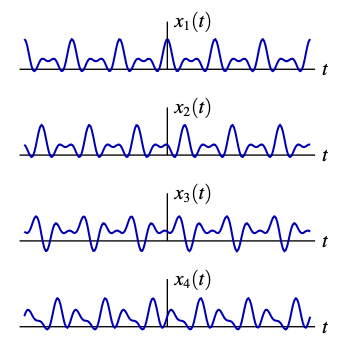

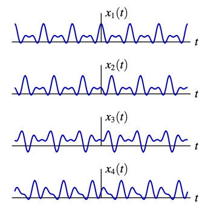

## 幅值与相位

[figure not shown]

上面一行，分别为：$X$、$|X|$和$\arg X$

下面一行，分别为：$\mathcal{F}^{-1}(|X|)$、$\mathcal{F}^{-1}(\arg X)$

## 目录

- 1. 傅里叶变换的模和相位表示
- **2. 线性时不变系统频率响应的模和相位表示**
- 3. 理想频率选择性滤波器的时域特性
- 4. 非理想频率选择性滤波器的时域特性
- 5. 一阶与二阶连续时间系统
- 6. 一阶与二阶离散时间系统
- 7. 系统的时域和频域分析实例

## LTI系统频率响应的模–相位表示

对于线性时不变系统，对输入信号所起的作用包括两个方面：

- 改变输入信号各频率分量的幅度；
- 改变输入信号各频率分量的相对相位。

对于线性时不变系统

$$Y(j \omega)=H(j \omega) X(j \omega), \quad Y\left(e^{j \omega}\right)=H\left(e^{j \omega}\right) X\left(e^{j \omega}\right)$$
其中，$H（j \omega）=|H(j \omega)| e^{j \arg H(j \omega)}$,$|H(j \omega)|$ 为幅值响应，$e^{j \arg H(j \omega)}$为相位响应。

以及

$$\arg Y=\arg H+\arg X, \quad \arg H \text{表示系统引入的相移(phase shift) }$$

LTI 系统带来的影响，可能是我们希望得到的，也可能不是。

- 若这种影响不是我们想要的，则称为失真(distortion)。
- 根据组成，失真包含幅度失真和相位失真两种。

## LTI系统频率响应的模–相位表示

1．幅度失真：由于频谱的模改变而引起的失真。各频率分量幅度产生不同程度的衰减。

2．相位失真：由于频谱的相位改变引起的失真。各频率分量产生的相移不与频率成正比，使响应的各频率分量在时间轴上的相对位置产生变化。

在工程实际中，不同的应用场合，对幅度失真和相位失真有不同的敏感程度，也会有不同的技术指标要求。

- 模拟信号一旦发生失真，在以后的处理中，将保持这种失真-（称为失真信号的继承性）。

**无失真传输**

- 理想情况下，$H(j \omega)=1$（或$H(j \omega)=K$），但这对应于非因果系统；
- 当 $H(j \omega)=K e^{-j \omega t_{0}}$ 时，系统保持波形形状不变，只引入幅值缩放和时延。

称为**无失真传输**，这种系统为**全通系统**。

在无失真传输的情况下，相位严格正比于频率：$\phi(\omega) = -t_0 \omega$，这种相位特性称为**线性相位**。

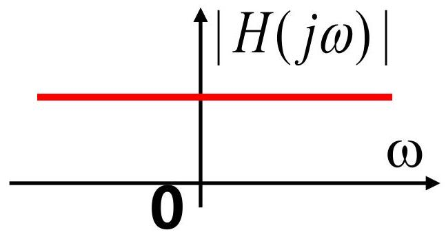

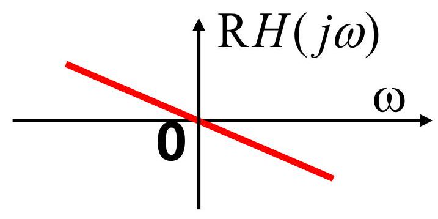

## 线性相位和非线性相位

在滤波中，我们往往希望系统产生特定效果；

若这种影响不是我们想要的，则称为失真(distortion)。

总的来说，失真包含幅度失真和相位失真两种。

模拟信号一旦发生失真，在以后的处理中，将保持这种失真-失真信号的继承性。

例：无失真传输

- 理想情况下，$H(j \omega)=1$，但这对应于非因果系统；
- 当 $H(j \omega)=K e^{-j \omega t_{0}}$ 时，系统保持波形形状不变，只引入幅值缩放和时延。

## 线性相位

对于具有单位增益和线性相位的连续时间 LTI 系统

$$H(j \omega)=e^{-j \omega t_{0}} \Longrightarrow y(t)=x\left(t-t_{0}\right)$$

输出是输入的延时版本

对于具有单位增益和线性相位的离散时间 LTI 系统

$$H\left(e^{j \omega}\right)=e^{-j \omega n_{0}},$$

即LTI仅附加一个线性相移，输出信号则只是在时间上的平移

$$y[n]=\frac{1}{2 \pi} \int_{-\pi}^{\pi} X\left(e^{j \omega}\right) e^{-j \omega n_{0}} e^{j \omega n} d \omega=\sum_{m=-\infty}^{\infty} x[m] \operatorname{sinc}\left(n-n_{0}-m\right)$$
此时并未丟失信号所携带的任何信息，只是发生时间上的延迟，因而在工程应用中是允许的。

输出为

$$y[n]=\frac{1}{2 \pi} \int_{-\pi}^{\pi} X\left(e^{j \omega}\right) e^{-j \omega n_{0}} e^{j \omega n} d \omega=\sum_{m=-\infty}^{\infty} x[m] \operatorname{sinc}\left(n-n_{0}-m\right)$$

- 当 $n_{0}$ 为整数时，$y[n]=x\left[n-n_{0}\right]$，即输出是输入的整数点延时版本；
- 当 $n_{0}$ 为非整数时，$y[n]=y_{c}\left(n-n_{0}\right)$，它是信号包络 $y_{c}(t)=\sum_{m=-\infty}^{\infty} x[m] \operatorname{sinc}(t-m)$ 延时后的采样值。

## 线性相位和非线性相位

物理本质：**时间延迟的一致性**

设想输入信号由不同频率的分量组成，若要保证信号波形不失真，就必须要求所有频率分量经过系统后，被延迟的时间必须完全相同：

根据傅里叶变换的时移性质：
$$x(t - t_0) \leftrightarrow X(j\omega)e^{-j\omega t_0}$$

- 频率为 $\omega_1$ 的分量，其相位偏移是 $-\omega_1 t_0$
- 频率为 $\omega_2$ 的分量，其相位偏移是 $-\omega_2 t_0$

结论： 只有当相位响应 $\phi(\omega)$ 是频率的线性函数时，不同频率的分量才会有相同的“时间延迟”。

如果相位与频率不是线性关系（例如 $\phi(\omega) = \omega^2$），高频分量和低频分量延迟的时间就不一样，输出信号的波形就会发生“相位失真”。

## 线性相位

$$H(j \omega)=e^{-j \omega / 2}$$

对于输入

$x(t)=\sum_{k=0}^{3} \cos (2 k \pi t)=1+\cos (2 \pi t)+\cos (4 \pi t)+\cos (6 \pi t)$

输出为

$y(t)=\sum_{k=0}^{3} \cos (2 k \pi t-k \pi)=x\left(t-\frac{1}{2}\right)$

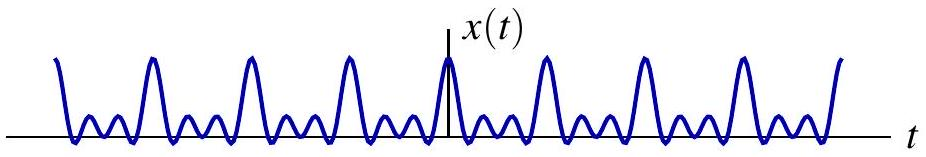

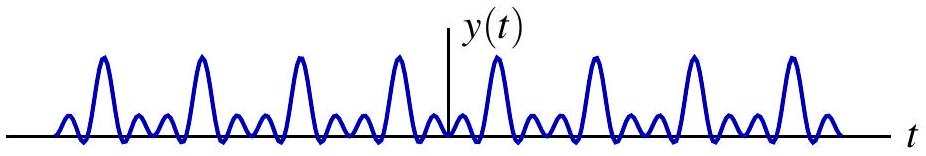

## 线性相位

半采样延时

$$H\left(e^{j \omega}\right)=e^{-j \omega / 2}$$

对于输入

$x[n]=\cos \left(\frac{\pi}{3} n\right)$

输出为

$y[n]=\sum_{m=-\infty}^{\infty} \cos \left(\frac{\pi}{3} m\right) \operatorname{sinc}\left(n-n_{0}-m\right)=\cos \left(\frac{\pi}{3}\left[n-\frac{1}{2}\right)\right]$

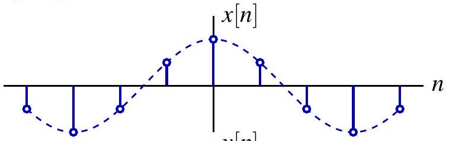

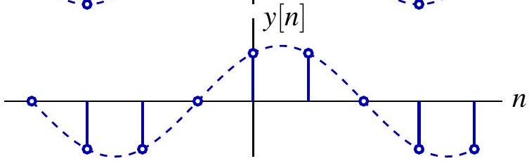

## 非线性相位

$$H(j \omega)=e^{-j \arctan \omega}$$

对于输入

$x(t)=\sum_{k=0}^{3} \cos (2 k \pi t)=1+\cos (2 \pi t)+\cos (4 \pi t)+\cos (6 \pi t)$

输出为

$y(t)=\sum_{k=0}^{3} \cos [2 k \pi t-\arctan (2 k \pi)]$

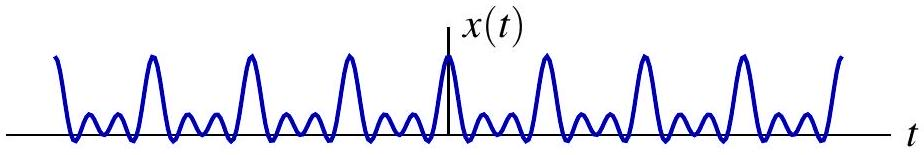

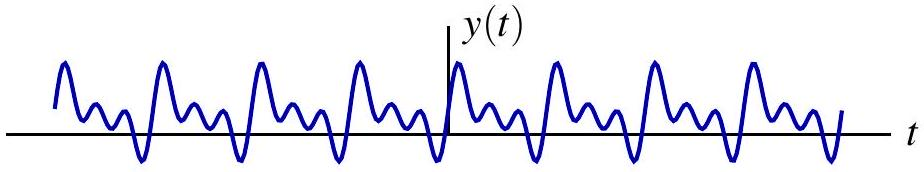

## 群时延

对于以 $\omega_{0}$ 为中心的窄带输入信号 $x$，即

对相位作线性近似

$$\arg H(j \omega) \approx \arg H\left(j \omega_{0}\right)-\tau\left(\omega_{0}\right)\left(\omega-\omega_{0}\right)=-\phi_{0}-\tau\left(\omega_{0}\right) \omega$$

其中，在频率 $\omega$ 处的**群时延**定义为

$$\tau(\omega)=-\frac{d}{d \omega} \arg H(j \omega)$$

群时延代表了在以 $\omega_{0}$ 为中心的一个很窄的频带或很少的一组频率上信号所受到的有效公共延时。
如果当 $\left|\omega-\omega_{0}\right| \leq \Delta \omega$ 时，$|H(j \omega)| \approx\left|H\left(j \omega_{0}\right)\right|$，
$$Y(j \omega) \approx\left|H\left(j \omega_{0}\right)\right| X(j \omega) e^{-j \phi_{0}-j \tau\left(\omega_{0}\right) \omega} \Longrightarrow y(t) \approx\left|H\left(j \omega_{0}\right)\right| e^{-j \phi_{0}} x\left(t-\tau\left(\omega_{0}\right)\right)$$

## 群时延

其中，在频率 $\omega$ 处的群时延定义为

$$\tau(\omega)=-\frac{d}{d \omega} \arg H(j \omega)$$

如果当 $\left|\omega-\omega_{0}\right| \leq \Delta \omega$ 时，$|H(j \omega)| \approx\left|H\left(j \omega_{0}\right)\right|$， $Y(j \omega) \approx\left|H\left(j \omega_{0}\right)\right| X(j \omega) e^{-j \phi_{0}-j \tau\left(\omega_{0}\right) \omega} \Longrightarrow y(t) \approx\left|H\left(j \omega_{0}\right)\right| e^{-j \phi_{0}} x\left(t-\tau\left(\omega_{0}\right)\right)$

## **群时延**

$$H(j \omega)=e^{-j \arctan \omega} \Longrightarrow \tau(\omega)=\frac{d}{d \omega} \arctan (\omega)=\frac{1}{1+\omega^{2}}$$

对于输入信号（它可看作以 $\pm \pi$ 为中心的两个窄带信号 $z, \bar z$ 之和） $x(t)=\sum_{k=9}^{11} \cos \left(\frac{k \pi}{10} t\right)=\operatorname{Re} z(t)=\frac{1}{2} z(t)+\frac{1}{2} \bar{z}(t)$，其中 $z(t)=\sum_{k=9}^{11} e^{j \frac{k \pi}{10} t}$，输出近似为

$$y(t) \approx \frac{1}{2} e^{-j \phi_{0}} z\left(t-\tau_{0}\right)+\frac{1}{2} e^{j \phi_{0}} \bar{z}\left(t-\tau_{0}\right)=\operatorname{Re}\left[e^{-j \phi_{0}} z\left(t-\tau_{0}\right)\right]$$

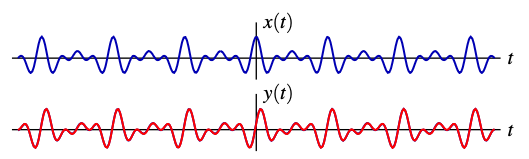

## 对数模和伯德图（Bode Diagram）

对数模：$|Y(j \omega)|= |H(j \omega)| |X(j \omega)| \Longrightarrow \log |Y(j \omega)|=\log |H(j \omega)|+\log |X(j \omega)|$

**一般采用对数标尺以 $20 \log _{10}$ 为单位，称之为分贝 （dB）**

- **0 dB**：模等于 1（无增益/衰减）
- **20 dB**：10 倍单位增益
- **-20 dB**：0.1 倍衰减
- 对于连续时间系统，常采用对数频率坐标

  $\mathbf{2 0 l o g}_{\mathbf{1 0}}|\boldsymbol{H}(\mathbf{j} \omega)|$和 $\arg \boldsymbol{H}(\boldsymbol{j} \omega)$ 对 $\boldsymbol{\operatorname { l o g }}_{\mathbf{1 0}}(\omega)$ 作的图称之为伯德图。
- 对数频率坐标，常常可以比线性频率展示宽的多的频率范围。

在离散时间情况下，傅里叶变换和频率响应的模常常也是用dB来表示的。

**在离散时间情况下对数频率坐标一般是不用的，**

因为这时要考虑的频率范围就只有 $2 \pi$ 宽，$H\left(e^{j \omega}\right)$ 是周期的。

注意：**对实值 $h[n]$ ，仅需画出 $[0, \pi]$ 范围的 $H\left(e^{j \omega}\right)$**

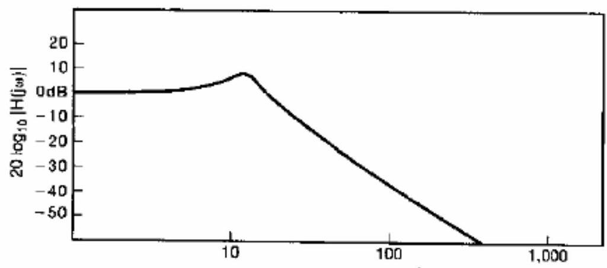

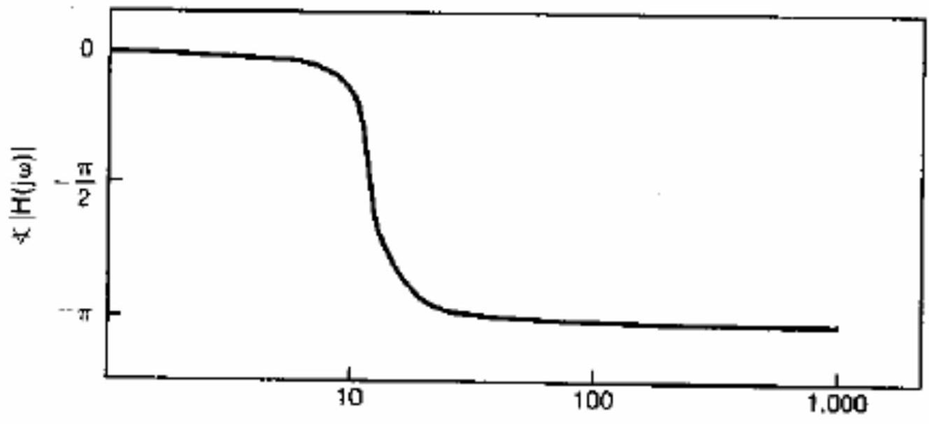

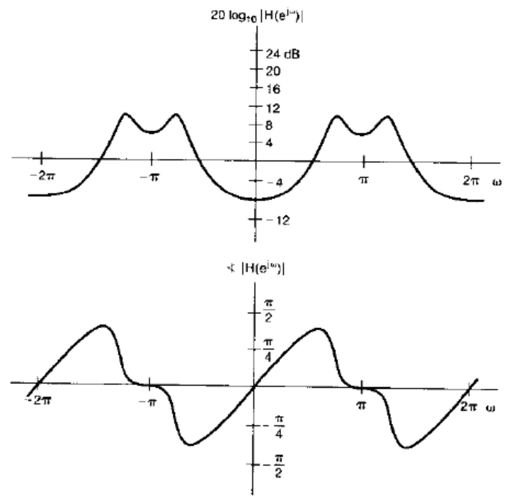

## 对数模和伯德图（Bode Diagram）

$$H(j \omega)=\frac{\sum_{k=0}^{N} b_{k}(j \omega)^{k}}{\sum_{k=0}^{N} a_{k}(j \omega)^{k}}=\frac{N(j \omega)}{D(j \omega)}=H_0 \frac{\prod_{j=1}^m (j\omega - z_j)}{\prod_{i=1}^n (j\omega - p_i)}$$

其中：

- $z_j$ 为系统的**零点**。
- $p_i$ 为系统的**极点**。
- $H_0$ 为系统增益常数。

**几何矢量解释**

$(j\omega - z_j)$ 或 $(j\omega - p_i)$ 都可以看作是从零/极点指向虚轴上 $j\omega$ 点的一个**矢量**。

- **零点矢量**：$j\omega - z_j = N_j e^{j\psi_j}$
- **极点矢量**：$j\omega - p_i = M_i e^{j\theta_i}$

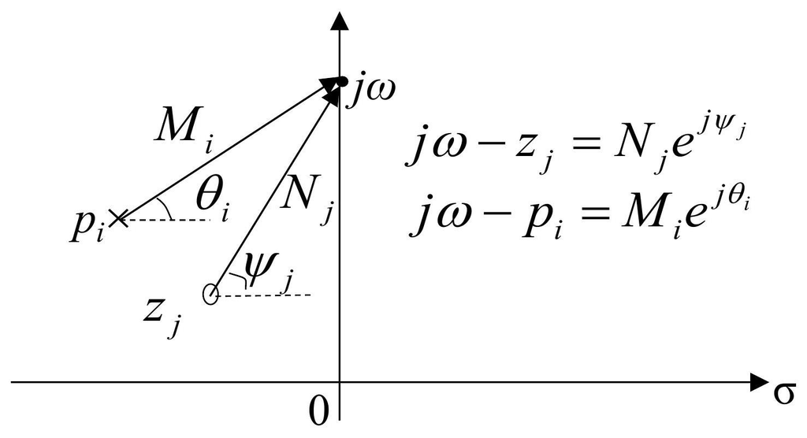

## 对数模和伯德图（Bode Diagram）

**模值的对数化（幅频特性）**

对 $H(j\omega)$ 取模并取对数（单位：dB）：
$$20 \log_{10} |H(j\omega)| = 20 \log_{10} |H_0| + \sum_{j=1}^m 20 \log_{10} N_j - \sum_{i=1}^n 20 \log_{10} M_i$$

- **叠加性**：Bode图的幅频特性曲线本质上是所有零点和极点矢量长度（对数化后）的纵向叠加。
- **转折频率**：当 $\omega$ 靠近某个极点或零点的模值时，该矢量长度的变化最剧烈，对应Bode图上的斜率转折（±20dB/dec）。

**相位的线性叠加（相频特性）**

系统的总相位响应为：
$$\angle H(j\omega) = \sum_{j=1}^m \psi_j - \sum_{i=1}^n \theta_i$$

模的关系涉及 $|\boldsymbol{H}(\boldsymbol{j} \omega)|$ 和 $|\boldsymbol{X}(\boldsymbol{j} \omega)|$ 的相乘。因此，如果傅里叶变换的模是在一个对数幅度上展示的话，那么就有一个相加的关系：

$$\log |Y(j \omega)|=\log |H(j \omega)|+\log |X(j \omega)|$$
* 在一个对数标尺上展现傅里叶变换的模，还能在一个较宽的动态范围上将细节显示出来。

- 一般所采用的对数标尺是以 $20 \log _{10}$ 为单位，称之为分贝 （dB）。
- 0dB就对应于频率响应的模等于 1
- 20dB就对应于10倍的单位增益
- －20dB相应于衰减0．1。
- 对于连续时间系统，常采用对数频率坐标。 $\mathbf{2 0 l o g}_{\mathbf{1 0}}|\boldsymbol{H}(\mathbf{j} \omega)|$和 $\arg \boldsymbol{H}(\boldsymbol{j} \omega)$ 对 $\boldsymbol{\operatorname { l o g }}_{\mathbf{1 0}}(\omega)$ 作的图称之为伯德图。
- 对数频率坐标，常常可以比线性频率展示宽的多的频率范围。

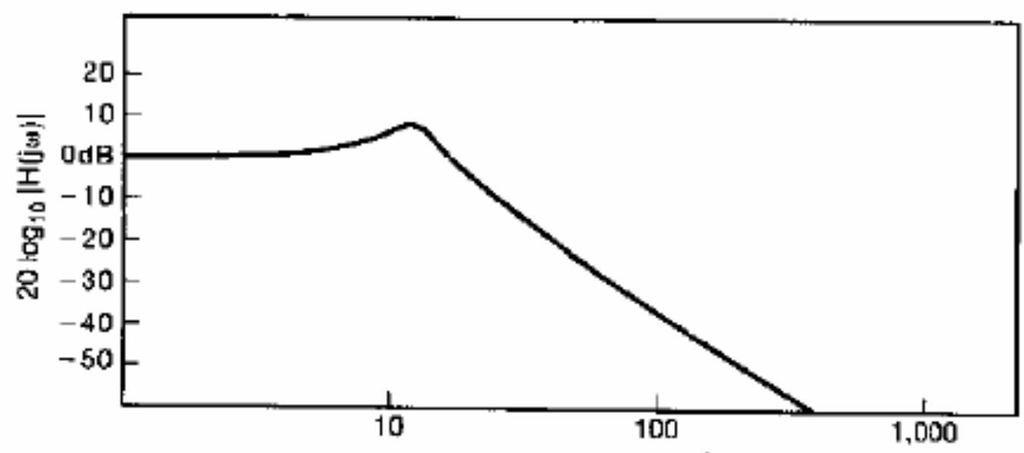

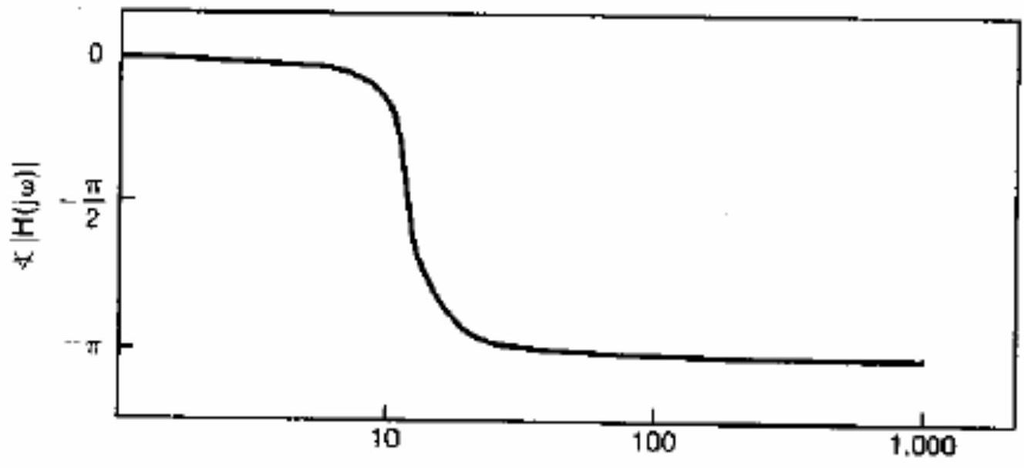

## 对数模和伯德图（Bode Diagram）

[output not shown]

在离散时间情况下，傅里叶变换和频率响应的模常常也是用dB来表示的。然而，在离散时间情况下对数频率坐标一般是不用的，因为这时要考虑的频率范围就只有 $2 \pi$ 宽，$H\left(e^{j \omega}\right)$ 是周期的。 ＊注意，对实值 $h[n]$ ，仅需画出 $[0, \pi]$ 范围的 $H\left(e^{j \omega}\right)$

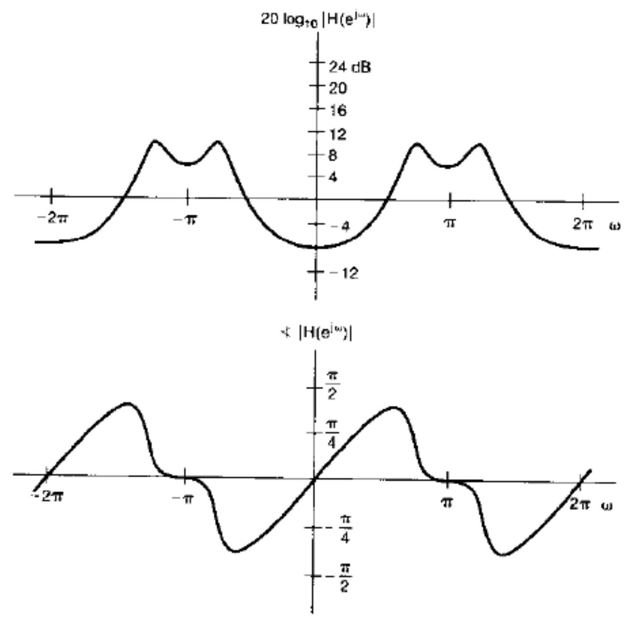

## 目录

- 1. 傅里叶变换的模和相位表示
- 2. 线性时不变系统频率响应的模和相位表示
- **3. 理想频率选择性滤波器的时域特性**
- 4. 非理想频率选择性滤波器的时域特性
- 5. 一阶与二阶连续时间系统
- 6. 一阶与二阶离散时间系统
- 7. 系统的时域和频域分析实例

## （The Ideal Frequency－Selective Filters）

一．滤波 通过系统改变信号中各频率分量的相对大小和相位，甚至完全去除某些频率分量的过程称为滤波。滤波器可分为两大类：

1．频率成形滤波器（改变各分量的幅度与相位） 2．频率选择性滤波器（去除某些频率分量）

## 二．理想频率选择性滤波器的频率特性

理想频率选择性滤波器的频率特性在某一个（或几个）频段内，频率响应为常数，而在其它频段内频率响应等于零。

理想滤波器可分为低通、高通、带通、带阻。 滤波器允许信号完全通过的频段称为滤波器的通带（pass band），完全不允许信号通过的频段称为阻带（stop band）。

## 连续时间理想频率选择性滤波器的频率特性

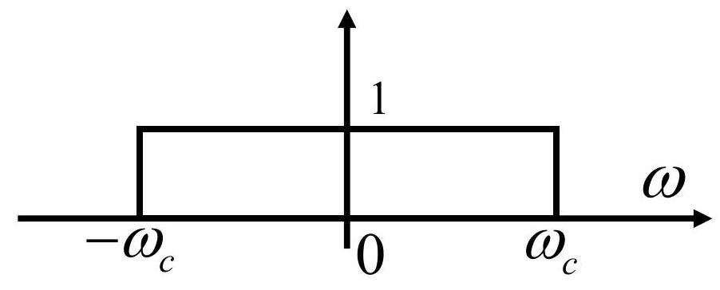

低通

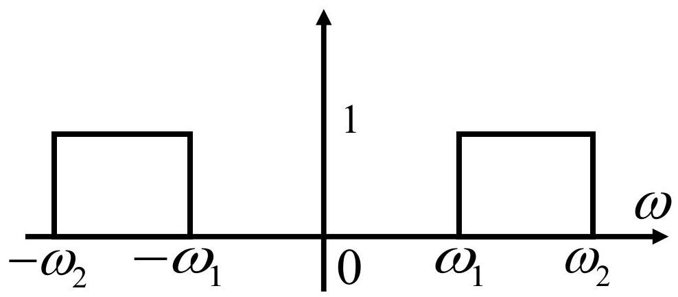

带通

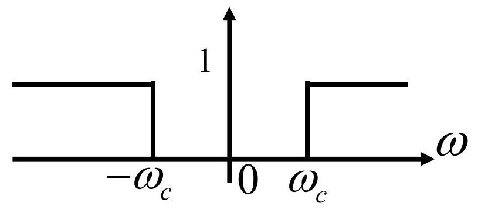

高通

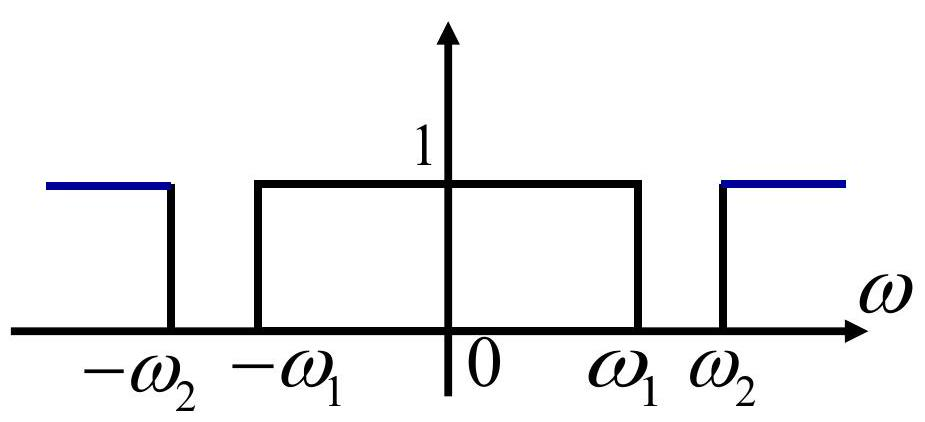

带阻

## 离散时间理想频率选择性滤波器的频率特性

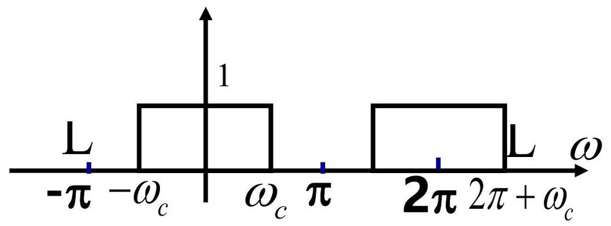

低通

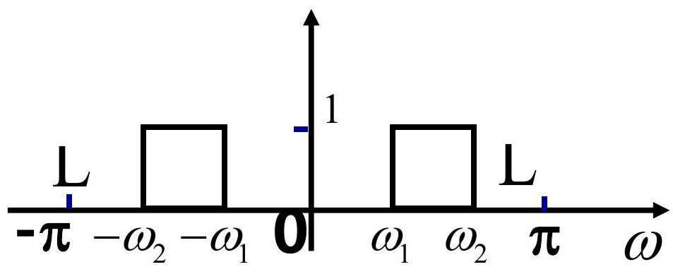

带通

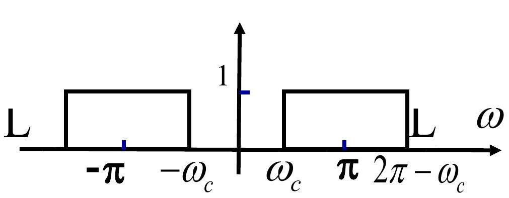

高通

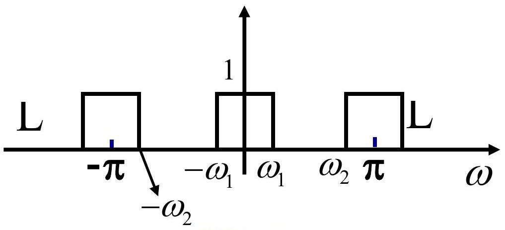

带阻

三．理想滤波器的时域特性 以理想低通滤波器为例

$$H(j \omega)= \begin{cases}1, & |\omega|<\omega_{c} \\ 0, & |\omega|>\omega_{c}\end{cases}$$

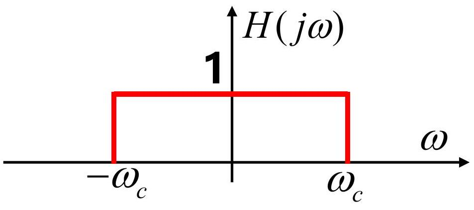

连续时间理想低通滤波器

## 由傅里叶变换可得：

$$h(t)=\frac{1}{2 \pi} \int_{-\omega_{c}}^{\omega_{c}} e^{j \omega t} d \omega=\frac{\sin \omega_{c} t}{\pi t}=\frac{\omega_{c}}{\pi} \operatorname{Sa}\left(\omega_{c} t\right)$$

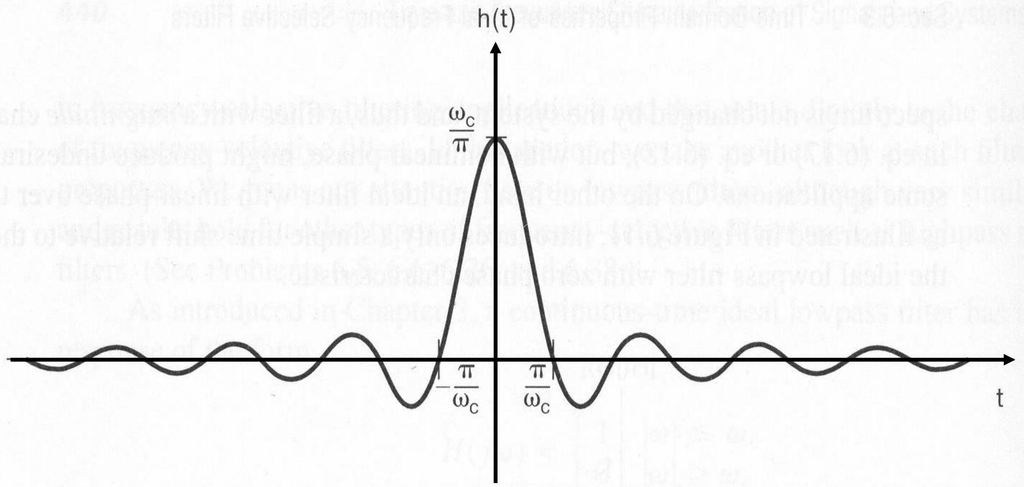

对离散时间理想低通滤波器有：

$$h(n)=\frac{\sin \omega_{c} n}{\pi n}=\frac{\omega_{c}}{\pi} \operatorname{Sa}\left(\omega_{c} n\right)$$

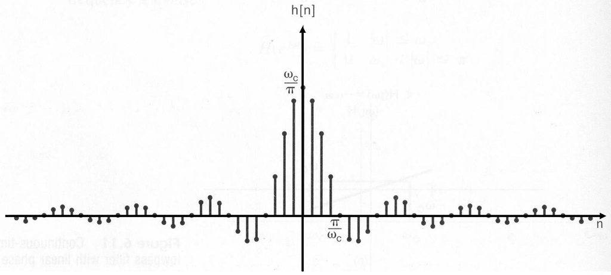

## 如果理想低通滤波器具有线性相位特性

$$H(j \omega)= \begin{cases}e^{-j \alpha \omega}, & |\omega|<\omega_{c} \\ 0, & |\omega|>\omega_{c}\end{cases}$$

则 $h(t)=\frac{\omega_{c}}{\pi} \mathrm{Sa}\left[\omega_{c}(t-\alpha)\right]=\frac{\sin \omega_{c}(t-\alpha)}{\pi(t-\alpha)}$

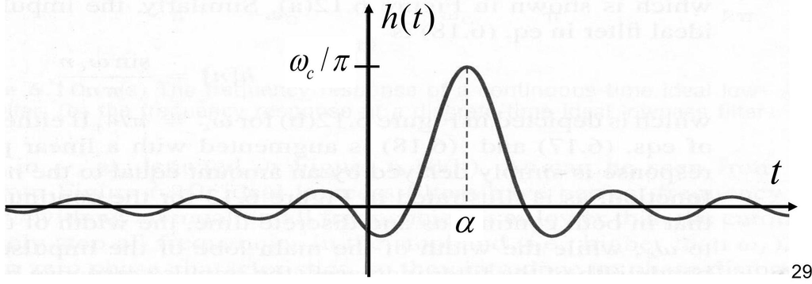